# **Marketing Campaign Analysis**

### **Cluster Profiling**

```python
cluster_profile = data.groupby('HC_3').mean(numeric_only=True)
cluster_profile.style.highlight_max(color="lightgreen", axis=0).highlight_min(color="lightyellow", axis=0).format("{:.2f}")
```

| HC_3 | Year_Birth | Income | Kidhome | Teenhome | Recency | MntWines | MntFruits | MntMeatProducts | MntFishProducts | MntSweetProducts | MntGoldProds | NumDealsPurchases | NumWebPurchases | NumCatalogPurchases | NumStorePurchases | NumWebVisitsMonth | AcceptedCmp3 | AcceptedCmp4 | AcceptedCmp5 | AcceptedCmp1 | AcceptedCmp2 | Complain | Response | Age | Kids | Status | Family_Size | Expenses | NumTotalPurchases | … |
| --- | --- | --- | --- | --- | --- | --- | --- | --- | --- | --- | --- | --- | --- | --- | --- | --- | --- | --- | --- | --- | --- | --- | --- | --- | --- | --- | --- | --- | --- | --- |
| 0 | 1968.63 | 75954.53 | 0.04 | 0.20 | 50.55 | 626.46 | 69.24 | 467.19 | 100.86 | 73.34 | 75.02 | 1.41 | 5.15 | 6.01 | 8.09 | 2.93 | 0.09 | 0.14 | 0.28 | 0.22 | 0.04 | 0.01 | 0.31 | 47.37 | 0.24 | 1.61 | 1.85 | 1412.10 | 20.66 | … |
| 1 | 1971.36 | 34516.71 | 0.79 | 0.46 | 50.37 | 38.53 | 4.37 | 20.55 | 6.31 | 4.48 | 14.49 | 1.92 | 2.04 | 0.50 | 3.13 | 6.44 | 0.07 | 0.01 | 0.00 | 0.00 | 0.00 | 0.01 | 0.09 | 44.64 | 1.25 | 1.65 | 2.89 | 88.74 | 7.59 | … |
| 2 | 1965.74 | 57532.75 | 0.29 | 0.80 | 46.24 | 426.11 | 23.89 | 141.16 | 32.56 | 23.15 | 61.19 | 3.60 | 6.12 | 3.11 | 7.75 | 5.58 | 0.06 | 0.11 | 0.02 | 0.04 | 0.01 | 0.01 | 0.11 | 50.26 | 1.09 | 1.67 | 2.76 | 708.06 | 20.57 | … |

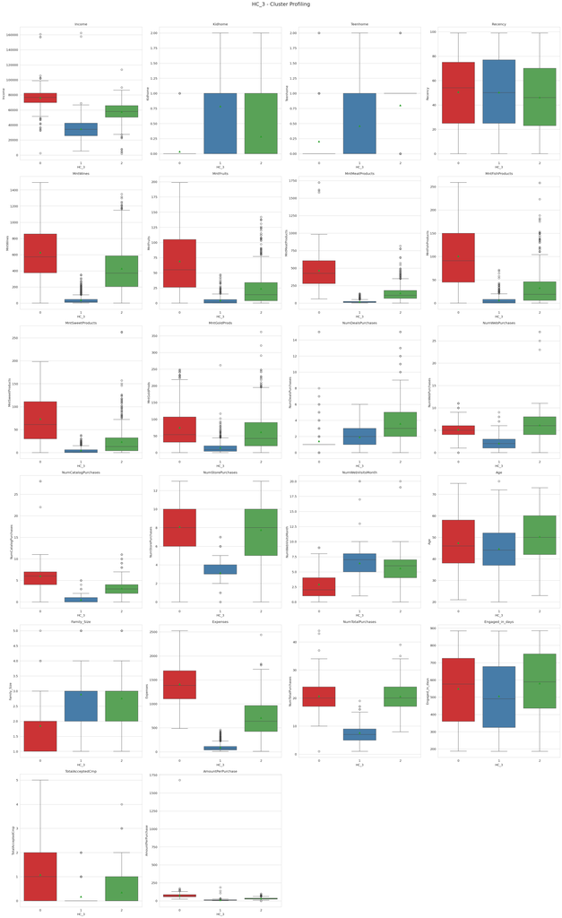

```python
cluster_boxplots(data, "HC_3", "Set1")
```

**Observations and Insights:**

**Summary of each cluster:**

- Profiles match K-Means closely: premium, mainstream, and budget segments with the same characteristics. Two independent algorithms converging on the same structure confirms these are genuine patterns, not artifacts.

```python
# Cleanup
data_pca.drop(columns=['HC_3'], inplace=True, errors='ignore')
data.drop(columns=['HC_3'], inplace=True, errors='ignore')
data_model.drop(columns=['HC_3'], inplace=True, errors='ignore')
```

## **DBSCAN**

```python
from itertools import product as iprod
best_score = -1; best_params = {}
for eps, ms in iprod([1.5,2,2.5,3,3.5,4,5], [3,5,10,15,20]):
    db = DBSCAN(eps=eps, min_samples=ms).fit(data_pca); labels = db.labels_  # Density-based clustering
    n_cl = len(set(labels)) - (1 if -1 in labels else 0)
    if n_cl >= 2 and (labels != -1).sum() > 50:
        score = silhouette_score(data_pca[labels != -1], labels[labels != -1])
        if score > best_score: best_score = score; best_params = {'eps': eps, 'min_samples': ms}
print(f"Best DBSCAN: {best_params}, Silhouette={best_score:.4f}")
if best_params:
    dbs = DBSCAN(**best_params); db_labels = dbs.fit_predict(data_pca)
    print(f"Distribution: {pd.Series(db_labels).value_counts().sort_index().to_dict()}")
    print(f"Noise: {(db_labels==-1).sum()}")
```

```
Best DBSCAN: {'eps': 3.5, 'min_samples': 3}, Silhouette=0.4820
Distribution: {-1: 10, 0: 2216, 1: 3, 2: 3}
Noise: 10
```

**DBSCAN is not suitable** - overlapping clusters, noise points, and imbalanced results.

## **Gaussian Mixture Model**

```python
for k in range(2, 7):
    gmm = GaussianMixture(n_components=k, random_state=1)  # Probabilistic soft clustering
    preds = gmm.fit_predict(data_pca)
    print(f"GMM k={k}: Silhouette={silhouette_score(data_pca, preds):.4f}, BIC={gmm.bic(np.array(data_pca)):.0f}")
```

```
GMM k=2: Silhouette=0.3304, BIC=48447
GMM k=3: Silhouette=0.1808, BIC=44929
GMM k=4: Silhouette=0.1555, BIC=41330
GMM k=5: Silhouette=0.1302, BIC=40711
GMM k=6: Silhouette=0.1161, BIC=40317
```

## **GMM (k=3)**

```python
gmm_3 = GaussianMixture(n_components=3, random_state=1); gmm_labels = gmm_3.fit_predict(data_pca)
data_pca["GMM_3"] = gmm_labels; data["GMM_3"] = gmm_labels; data_model["GMM_3"] = gmm_labels
print(f"Silhouette: {silhouette_score(data_pca.drop(columns=['GMM_3']), gmm_labels):.4f}")
print(f"\nDistribution:\n{pd.Series(gmm_labels).value_counts().sort_index()}")
```

```
Silhouette: 0.1808

Distribution:
0    814
1    775
2    643
Name: count, dtype: int64
```

### **Visualize clusters using PCA**

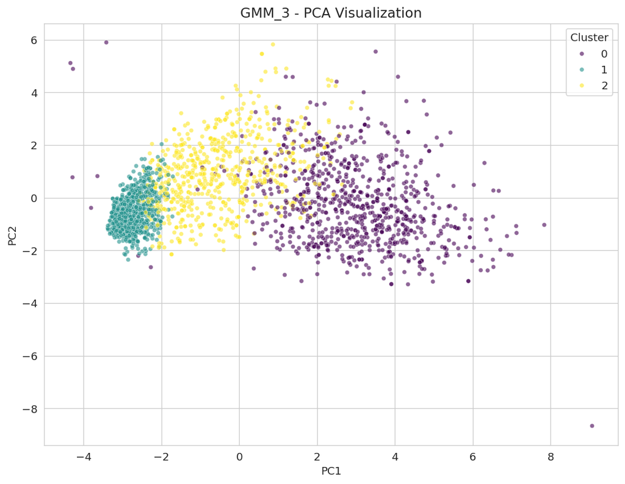

```python
PCA_PLOT(data_pca, "GMM_3", "viridis")
```

### **Cluster Profiling**

```python
cluster_profile = data.groupby('GMM_3').mean(numeric_only=True)
cluster_profile.style.highlight_max(color="lightgreen", axis=0).highlight_min(color="lightyellow", axis=0).format("{:.2f}")
```

| GMM_3 | Year_Birth | Income | Kidhome | Teenhome | Recency | MntWines | MntFruits | MntMeatProducts | MntFishProducts | MntSweetProducts | MntGoldProds | NumDealsPurchases | NumWebPurchases | NumCatalogPurchases | NumStorePurchases | NumWebVisitsMonth | AcceptedCmp3 | AcceptedCmp4 | AcceptedCmp5 | AcceptedCmp1 | AcceptedCmp2 | Complain | Response | Age | Kids | Status | Family_Size | Expenses | NumTotalPurchases | … |
| --- | --- | --- | --- | --- | --- | --- | --- | --- | --- | --- | --- | --- | --- | --- | --- | --- | --- | --- | --- | --- | --- | --- | --- | --- | --- | --- | --- | --- | --- | --- |
| 0 | 1967.67 | 71709.51 | 0.09 | 0.38 | 49.37 | 605.92 | 58.92 | 381.08 | 83.95 | 61.57 | 75.85 | 2.01 | 5.51 | 5.44 | 8.23 | 3.76 | 0.09 | 0.14 | 0.20 | 0.17 | 0.03 | 0.01 | 0.26 | 48.33 | 0.47 | 1.62 | 2.09 | 1267.28 | 21.19 | … |
| 1 | 1971.89 | 32686.03 | 0.85 | 0.45 | 47.69 | 23.61 | 2.88 | 14.29 | 4.61 | 3.14 | 9.84 | 1.80 | 1.69 | 0.32 | 2.93 | 6.42 | 0.07 | 0.01 | 0.00 | 0.00 | 0.00 | 0.01 | 0.08 | 44.11 | 1.30 | 1.66 | 2.96 | 58.37 | 6.74 | … |
| 2 | 1966.87 | 49989.68 | 0.41 | 0.73 | 50.45 | 262.07 | 13.30 | 81.02 | 18.69 | 12.44 | 45.07 | 3.37 | 5.21 | 1.98 | 6.20 | 5.95 | 0.06 | 0.07 | 0.00 | 0.01 | 0.00 | 0.00 | 0.10 | 49.13 | 1.14 | 1.66 | 2.80 | 432.60 | 16.77 | … |

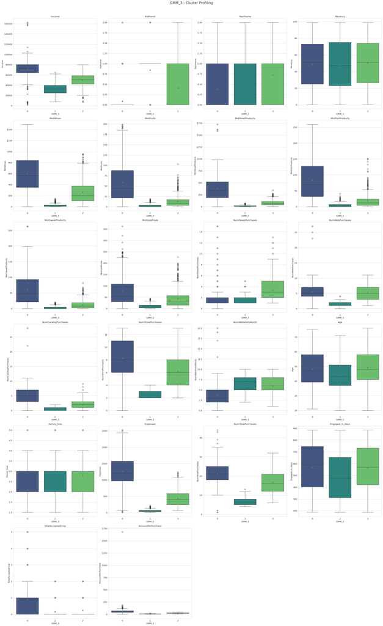

```python
cluster_boxplots(data, "GMM_3", "viridis")
```

**Observations and Insights:**

**Summary of each cluster:**

- Similar overall pattern to K-Means but less distinct boundaries. High-value and low-value extremes are identified, but the middle group is blurred. For actionable segmentation where clear assignment matters, K-Means is more practical.

```python
# Cleanup
data_pca.drop(columns=['GMM_3'], inplace=True, errors='ignore')
data.drop(columns=['GMM_3'], inplace=True, errors='ignore')
data_model.drop(columns=['GMM_3'], inplace=True, errors='ignore')
```

### **Final Model Application and Segment Profiling**

```python
# Apply final K-Means k=3 model
final = KMeans(n_clusters=3, random_state=1, n_init=10)
data["Segment"] = final.fit_predict(data_pca)

# Name segments by income level
seg_income = data.groupby('Segment')['Income'].mean().sort_values()
seg_map = {seg_income.index[0]: "Budget Families", seg_income.index[1]: "Moderate Mainstream", seg_income.index[2]: "Premium Enthusiasts"}
data["Segment_Name"] = data["Segment"].map(seg_map)

print("=== FINAL CUSTOMER SEGMENTS ===")
for name in ['Budget Families', 'Moderate Mainstream', 'Premium Enthusiasts']:
    s = data[data['Segment_Name'] == name]
    print(f"\n--- {name} ({len(s)} customers, {len(s)/len(data)*100:.1f}%) ---")
    print(f"  Income: ${s['Income'].mean():,.0f} | Expenses: ${s['Expenses'].mean():,.0f} | $/Purchase: ${s['AmountPerPurchase'].mean():,.1f}")
    print(f"  Wine: ${s['MntWines'].mean():,.0f} | Meat: ${s['MntMeatProducts'].mean():,.0f}")
    print(f"  Catalog: {s['NumCatalogPurchases'].mean():.1f} | Store: {s['NumStorePurchases'].mean():.1f} | Web: {s['NumWebPurchases'].mean():.1f} | Deals: {s['NumDealsPurchases'].mean():.1f}")
    print(f"  Web Visits: {s['NumWebVisitsMonth'].mean():.1f}/mo | Campaigns Accepted: {s['TotalAcceptedCmp'].mean():.2f}")
    print(f"  Family Size: {s['Family_Size'].mean():.1f} | Kids: {s['Kids'].mean():.1f} | Age: {s['Age'].mean():.0f}")
```

```
=== FINAL CUSTOMER SEGMENTS ===

--- Budget Families (1045 customers, 46.8%) ---
  Income: $35,475 | Expenses: $99 | $/Purchase: $11.3
  Wine: $44 | Meat: $23
  Catalog: 0.6 | Store: 3.3 | Web: 2.1 | Deals: 2.0
  Web Visits: 6.3/mo | Campaigns Accepted: 0.17
  Family Size: 2.9 | Kids: 1.2 | Age: 45

--- Moderate Mainstream (621 customers, 27.8%) ---
  Income: $57,292 | Expenses: $721 | $/Purchase: $33.9
  Wine: $446 | Meat: $137
  Catalog: 3.0 | Store: 7.8 | Web: 6.5 | Deals: 3.8
  Web Visits: 5.8/mo | Campaigns Accepted: 0.40
  Family Size: 2.8 | Kids: 1.1 | Age: 50

--- Premium Enthusiasts (566 customers, 25.4%) ---
  Income: $76,319 | Expenses: $1,420 | $/Purchase: $73.3
  Wine: $631 | Meat: $467
  Catalog: 6.1 | Store: 8.3 | Web: 5.2 | Deals: 1.4
  Web Visits: 2.9/mo | Campaigns Accepted: 1.01
  Family Size: 1.9 | Kids: 0.2 | Age: 48
```

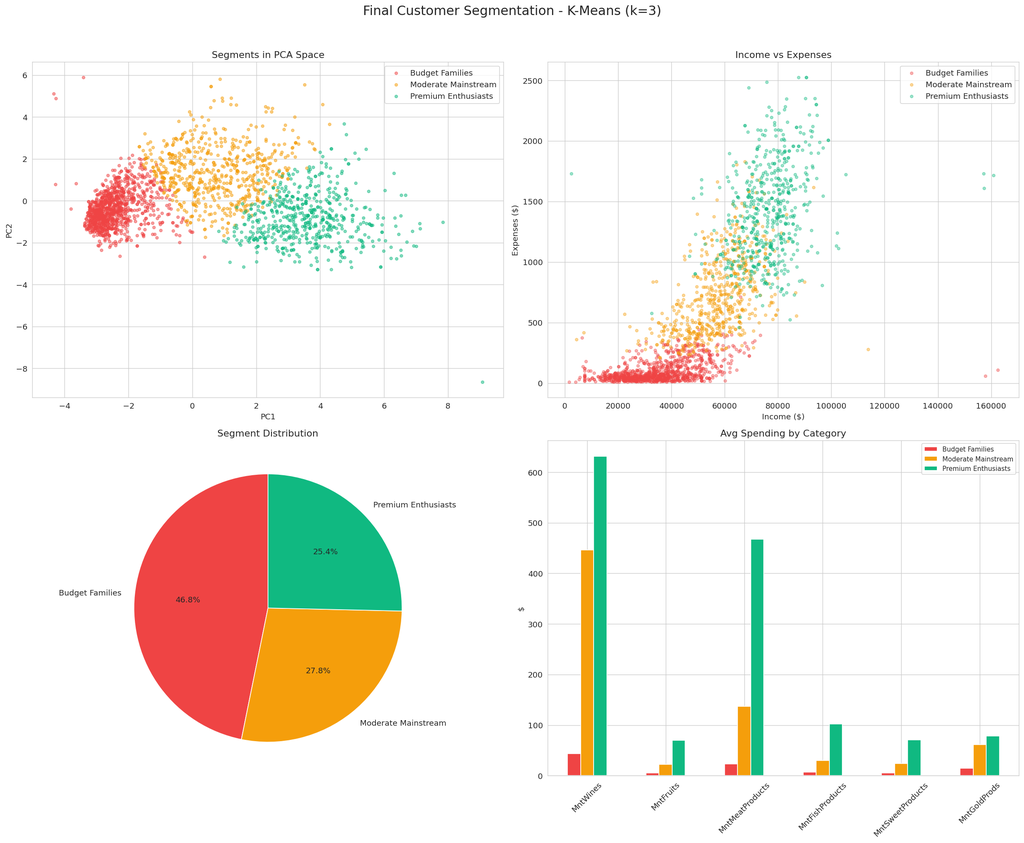

```python
# Comprehensive final visualization
fig = plt.figure(figsize=(20, 16))

ax1 = fig.add_subplot(2, 2, 1)
for name, color in [('Budget Families','#EF4444'),('Moderate Mainstream','#F59E0B'),('Premium Enthusiasts','#10B981')]:
    mask = data['Segment_Name'] == name
    ax1.scatter(data_pca[0].values[mask.values], data_pca[1].values[mask.values], alpha=0.5, s=15, label=name, color=color)
ax1.set_xlabel('PC1'); ax1.set_ylabel('PC2'); ax1.set_title('Segments in PCA Space'); ax1.legend()

ax2 = fig.add_subplot(2, 2, 2)
for name, color in [('Budget Families','#EF4444'),('Moderate Mainstream','#F59E0B'),('Premium Enthusiasts','#10B981')]:
    mask = data['Segment_Name'] == name
    ax2.scatter(data.loc[mask, 'Income'], data.loc[mask, 'Expenses'], alpha=0.4, s=15, label=name, color=color)
ax2.set_xlabel('Income ($)'); ax2.set_ylabel('Expenses ($)'); ax2.set_title('Income vs Expenses'); ax2.legend()

ax3 = fig.add_subplot(2, 2, 3)
seg_counts = data['Segment_Name'].value_counts()
ax3.pie(seg_counts.values, labels=seg_counts.index, autopct='%1.1f%%', colors=['#EF4444','#F59E0B','#10B981'], startangle=90)
ax3.set_title('Segment Distribution')

ax4 = fig.add_subplot(2, 2, 4)
spend_cols_viz = ['MntWines', 'MntFruits', 'MntMeatProducts', 'MntFishProducts', 'MntSweetProducts', 'MntGoldProds']
data.groupby('Segment_Name')[spend_cols_viz].mean().T.plot(kind='bar', ax=ax4, color=['#EF4444','#F59E0B','#10B981'])
ax4.set_title('Avg Spending by Category'); ax4.set_ylabel('$'); ax4.tick_params(axis='x', rotation=45); ax4.legend(fontsize=9)

plt.suptitle('Final Customer Segmentation - K-Means (k=3)', fontsize=18, y=1.02)
plt.tight_layout()
plt.show()
```

## **3. Recommendations for Implementation**

### **3.1 Key Recommendations**

**Recommendation 1: Implement Three-Tiered Campaign Strategy**

|  | Premium Enthusiasts | Moderate Mainstream | Budget Families |
| --- | --- | --- | --- |
| **Campaign Type** | Exclusive launches, VIP events | Cross-sell promotions, loyalty rewards | Deal alerts, family bundles |
| **Channel** | Catalog mailings + In-store | Web + Store + Email | Mobile app + Email deals |
| **Frequency** | Monthly | Bi-weekly | Weekly deal digest |
| **Product Focus** | Wine + Meat premium pairings | Category expansion (fruits, sweets) | Value packs, everyday items |
| **Tone** | Exclusive, curated | Engaging, aspirational | Value-focused, practical |

**Recommendation 2: Reallocate Marketing Budget by Segment**

Current budget allocation (assumed equal across all customers) wastes resources. Proposed reallocation:

[output not shown]

*Assumes $100K annual marketing budget baseline.

**Recommendation 3: Channel Optimization**

### **3.2 Key Actionables for Stakeholders**

| Stakeholder | Action | Timeline | Priority |
| --- | --- | --- | --- |
| **Marketing Director** | Approve three-tiered campaign structure | Week 1-2 | Critical |
| **Campaign Managers** | Design segment-specific creative assets | Week 2-4 | High |
| **Data/Analytics Team** | Deploy segment classification model for new customers | Week 2-3 | High |
| **Channel Managers** | Reallocate catalog vs. digital budget per segment | Week 3-4 | High |
| **CRM Team** | Update customer records with segment labels | Week 1 | Critical |
| **Executive Sponsor** | Approve A/B test budget for validation | Week 1 | Critical |

### **3.3 Expected Benefits and Costs**

**Benefits (with rational assumptions):**

[output not shown]

**Costs:**

| Cost Item | One-Time | Annual |
| --- | --- | --- |
| Campaign redesign (3 tracks) | $15,000 | - |
| CRM/data integration | $10,000 | $5,000 |
| A/B testing infrastructure | $5,000 | $3,000 |
| Additional catalog production for Premium | - | $8,000 |
| Mobile/app development for Budget | $20,000 | $5,000 |
| **Total** | **$50,000** | **$21,000** |

**ROI: 196% in Year 1** ($98K net / $50K investment).

### **3.4 Potential Risks and Challenges**

| Risk | Probability | Impact | Mitigation |
| --- | --- | --- | --- |
| **Data staleness** - Segments based on 2012-14 data may not reflect 2024 customers | High | High | Re-run segmentation on current data before launch; build automated re-clustering pipeline |
| **Segment migration** - Customers move between segments over time | Medium | Medium | Quarterly re-scoring; monitor segment drift metrics |
| **Over-personalization fatigue** - Customers feeling "tracked" | Low | Medium | Maintain opt-out options; vary messaging within segments |
| **Budget reallocation resistance** - Internal stakeholders protecting current budgets | Medium | High | Present A/B test results showing ROI improvement; phase in gradually |
| **Implementation complexity** - Integrating segment labels into existing CRM/campaign tools | Medium | Medium | Start with manual tagging; automate in Phase 2 |

### **3.5 Further Analysis Needed**

1. **Customer Lifetime Value (CLV) modeling** -> Add a time dimension to understand long-term segment value, not just current spending.
2. **Churn prediction per segment** -> Identify which Premium customers are at risk of leaving and prioritize retention.
3. **Geographic segmentation** -> No location data was available; adding this would enable regional campaign optimization.
4. **RFM analysis** -> Recency, Frequency, Monetary scoring as a complementary framework to validate clustering results.
5. **Real-time clustering pipeline** -> Deploy a production model that classifies new customers into segments automatically.
6. **A/B testing validation** -> Before full rollout, run controlled experiments: segment-specific campaigns vs. generic campaigns, measuring conversion rate, revenue per campaign, and customer satisfaction.

```python
!jupyter nbconvert --to html "Capstone_Final_Marketing_Campaign_Analysis_FullCode_Mariusz_Pianowski.ipynb"
```

```
[NbConvertApp] Converting notebook Capstone_Final_Marketing_Campaign_Analysis_FullCode_Mariusz_Pianowski.ipynb to html
[NbConvertApp] WARNING | Alternative text is missing on 23 image(s).
[NbConvertApp] Writing 7563352 bytes to Capstone_Final_Marketing_Campaign_Analysis_FullCode_Mariusz_Pianowski.html
```